# Latihan Pertemuan 4

Gladys Adya Zafira

2023-09-21

### Proses MA (2)

#### Bangkitkan Model MA (2) dengan θ1= 0.4 dan θ2=0.6 sebanyak 300 data (Manual dan arima.sim)

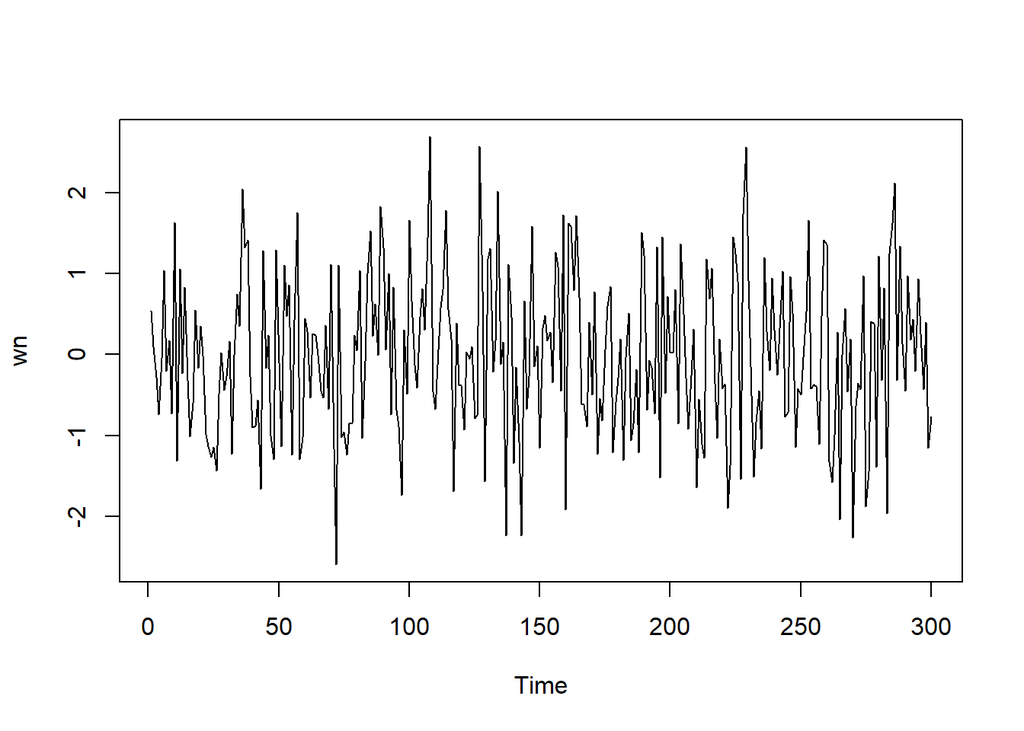

```r
wn <- rnorm(300)
ts.plot(wn)
```

```r
set.seed(1014)
```

#### Manual

```r
ma <- wn[c(1,2)]
ma
```

```
## [1] 0.54020393 0.09789459
```

```r
for(i in 3:300){
   ma[i] <- wn[i] + 0.4 * wn[i - 1] +0.6 * wn[i - 2]
}
ma
```

```
##   [1]  0.540203928  0.097894590  0.083458434 -0.789963494 -0.503164438
##   [6]  0.574562096  0.181639137  0.714347145 -0.783357002  1.443197455
##  [11] -1.095179301  1.505736036 -0.594877317  1.372563561 -0.116767613
##  [16] -0.636198060 -1.187910662 -0.299505943 -0.302193224  0.609626291
##  [21]  0.024934015 -0.782115212 -1.538116763 -2.311141894 -2.333091732
##  [26] -2.655255495 -1.748786669 -1.035412461 -0.720936513 -0.433984307
##  [31] -0.211797639 -1.325140326 -0.404089478  0.007656592  0.645738793
##  [36]  2.633595323  2.345718678  3.163498661  1.081935628 -0.157611023
##  [41] -1.396693764 -1.451054904 -2.414407376  0.280363696 -0.650674975
##  [46]  0.942686169 -1.001096313 -1.550922655  0.177224350 -0.358702501
##  [51] -0.393298646  0.588144127  0.236924318  1.706734401 -0.605181572
##  [56]  0.450592241  1.179221257 -0.332172503 -0.491942121 -0.734862521
##  [61] -0.148335885 -0.149759801  0.217872770  0.022050476  0.248496820
##  [66] -0.303986309 -0.711768697 -0.122706183 -0.850890838  1.060918135
##  [71] -1.121999133 -2.386798959 -0.631662247 -2.137326137 -0.700053984
```

[output cut: 45 more lines]

#### Arima.sim

```r
ma2 <- arima.sim(list(order=c(0,0,2), ma=c(0.4,0.6)),n=300)
ma2
```

```
## Time Series:
## Start = 1
## End = 300
## Frequency = 1
##   [1] -3.175162899 -0.827286498 -0.843033960  1.393689923 -0.989521386
##   [6] -0.287005403 -1.436220324 -0.528780473 -0.813301327  0.237879019
##  [11]  1.984398082 -0.427590219  1.099046126 -2.636634353 -0.959760942
##  [16] -1.379213811  0.208748070 -0.728437436  0.428322295  0.001768128
##  [21] -0.878470390  0.433729657  1.400889331  1.100622660  0.158277562
##  [26] -0.448756315 -1.394677490 -1.852685420 -0.165670043 -0.356805904
##  [31]  0.875498823  1.826916236  0.907668915  0.884947550 -1.896463423
##  [36] -1.123670437 -1.571193356  0.774387143  0.308890415  0.029275343
##  [41] -0.263593318 -0.654943397  0.314224799  2.782446356  1.415576680
##  [46]  2.249572167  0.377197330 -1.517817100  0.168315210 -1.045434442
##  [51]  0.213869998 -0.209199329 -0.086420526  0.573158399 -2.036447388
```

[output cut: 49 more lines]

#### Plot time series, plot ACF, plot PACF, plot EACF. Identifikasi apakah data tersebut stationer

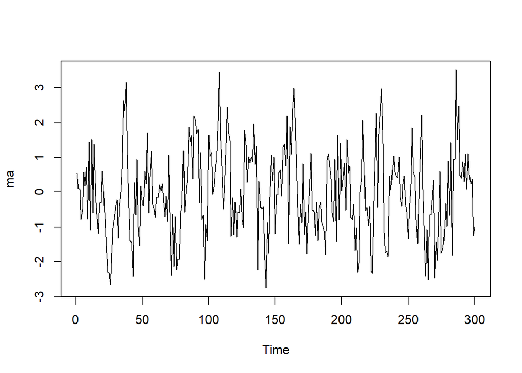

```r
ts.plot(ma)
```

Berdasarkan plot time series stasioner pada nilai rataan

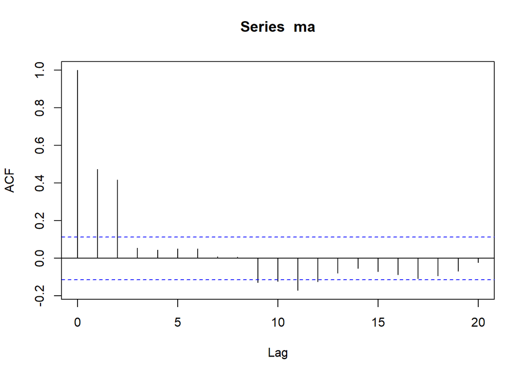

```r
acf(ma, lag.max=20)
```

Berdasarkan plot ACF tersebut, terlihat bahwa plot ACF *cuts off* di lag kedua

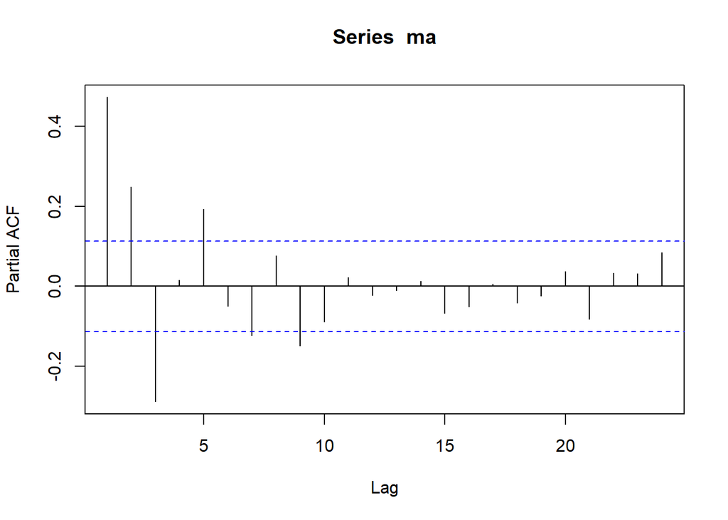

```r
pacf(ma)
```

Berdasarkan plot PACF tersebut, terlihat bahwa plot PACF cenderung *tails off* dan membentuk gelombang sinus

```r
TSA::eacf(ma)
```

```
## AR/MA
##   0 1 2 3 4 5 6 7 8 9 10 11 12 13
## 0 x x o o o o o o x x x  x  o  o
## 1 x x x o o o o o x o o  o  o  o
## 2 x x x x o o o o o o o  o  o  o
## 3 o x x o o o o o x o o  o  o  o
## 4 o x o o o o o o o o o  o  o  o
## 5 x x o o o o o o o o o  o  o  o
## 6 x x o o x x o x o o o  o  o  o
## 7 x x x x x x x o o o o  o  o  o
```

Berdasarkan pola segitiga nol pada plot EACF, terlihat bahwa segitiga nol berada pada ordo AR(0) dan ordo MA(2)

#### Scatterplot antara $Y_t$ dengan $Y_{t-1}$, $Y_t$ dengan $Y_{t-2}$, serta $Y_t$ dengan $Y_{t-3}$

```r
#Yt
yt_ma <- ma[-1]
yt_ma
```

```
##   [1]  0.097894590  0.083458434 -0.789963494 -0.503164438  0.574562096
##   [6]  0.181639137  0.714347145 -0.783357002  1.443197455 -1.095179301
##  [11]  1.505736036 -0.594877317  1.372563561 -0.116767613 -0.636198060
##  [16] -1.187910662 -0.299505943 -0.302193224  0.609626291  0.024934015
##  [21] -0.782115212 -1.538116763 -2.311141894 -2.333091732 -2.655255495
##  [26] -1.748786669 -1.035412461 -0.720936513 -0.433984307 -0.211797639
##  [31] -1.325140326 -0.404089478  0.007656592  0.645738793  2.633595323
##  [36]  2.345718678  3.163498661  1.081935628 -0.157611023 -1.396693764
##  [41] -1.451054904 -2.414407376  0.280363696 -0.650674975  0.942686169
##  [46] -1.001096313 -1.550922655  0.177224350 -0.358702501 -0.393298646
##  [51]  0.588144127  0.236924318  1.706734401 -0.605181572  0.450592241
##  [56]  1.179221257 -0.332172503 -0.491942121 -0.734862521 -0.148335885
##  [61] -0.149759801  0.217872770  0.022050476  0.248496820 -0.303986309
##  [66] -0.711768697 -0.122706183 -0.850890838  1.060918135 -1.121999133
##  [71] -2.386798959 -0.631662247 -2.137326137 -0.700053984 -2.231252380
```

[output cut: 45 more lines]

```r
#Yt-1
yt_1_ma <- ma[-300]
yt_1_ma
```

```
##   [1]  0.540203928  0.097894590  0.083458434 -0.789963494 -0.503164438
##   [6]  0.574562096  0.181639137  0.714347145 -0.783357002  1.443197455
##  [11] -1.095179301  1.505736036 -0.594877317  1.372563561 -0.116767613
##  [16] -0.636198060 -1.187910662 -0.299505943 -0.302193224  0.609626291
##  [21]  0.024934015 -0.782115212 -1.538116763 -2.311141894 -2.333091732
##  [26] -2.655255495 -1.748786669 -1.035412461 -0.720936513 -0.433984307
##  [31] -0.211797639 -1.325140326 -0.404089478  0.007656592  0.645738793
##  [36]  2.633595323  2.345718678  3.163498661  1.081935628 -0.157611023
##  [41] -1.396693764 -1.451054904 -2.414407376  0.280363696 -0.650674975
##  [46]  0.942686169 -1.001096313 -1.550922655  0.177224350 -0.358702501
##  [51] -0.393298646  0.588144127  0.236924318  1.706734401 -0.605181572
##  [56]  0.450592241  1.179221257 -0.332172503 -0.491942121 -0.734862521
##  [61] -0.148335885 -0.149759801  0.217872770  0.022050476  0.248496820
##  [66] -0.303986309 -0.711768697 -0.122706183 -0.850890838  1.060918135
##  [71] -1.121999133 -2.386798959 -0.631662247 -2.137326137 -0.700053984
```

[output cut: 45 more lines]

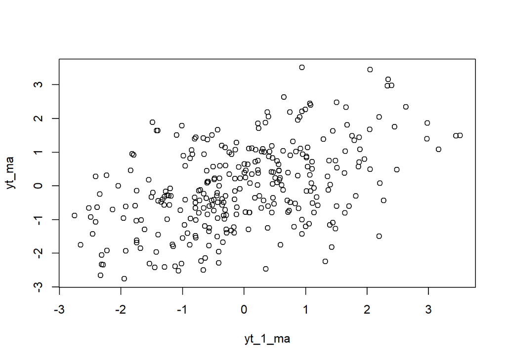

```r
plot(y=yt_ma,x=yt_1_ma)
```

Berdasarkan scatterplot tersebut, terlihat bahwa terdapat hubungan positif antara $Y_t$ dengan $Y_{t-1}$. Hal ini sesuai dengan teori yang ada

```r
cor(yt_ma,yt_1_ma)
```

```
## [1] 0.4735813
```

```r
#Yt
yt_ma2 <- ma[-c(1,2)]
yt_ma2
```

```
##   [1]  0.083458434 -0.789963494 -0.503164438  0.574562096  0.181639137
##   [6]  0.714347145 -0.783357002  1.443197455 -1.095179301  1.505736036
##  [11] -0.594877317  1.372563561 -0.116767613 -0.636198060 -1.187910662
##  [16] -0.299505943 -0.302193224  0.609626291  0.024934015 -0.782115212
##  [21] -1.538116763 -2.311141894 -2.333091732 -2.655255495 -1.748786669
##  [26] -1.035412461 -0.720936513 -0.433984307 -0.211797639 -1.325140326
##  [31] -0.404089478  0.007656592  0.645738793  2.633595323  2.345718678
##  [36]  3.163498661  1.081935628 -0.157611023 -1.396693764 -1.451054904
##  [41] -2.414407376  0.280363696 -0.650674975  0.942686169 -1.001096313
##  [46] -1.550922655  0.177224350 -0.358702501 -0.393298646  0.588144127
##  [51]  0.236924318  1.706734401 -0.605181572  0.450592241  1.179221257
##  [56] -0.332172503 -0.491942121 -0.734862521 -0.148335885 -0.149759801
##  [61]  0.217872770  0.022050476  0.248496820 -0.303986309 -0.711768697
##  [66] -0.122706183 -0.850890838  1.060918135 -1.121999133 -2.386798959
##  [71] -0.631662247 -2.137326137 -0.700053984 -2.231252380 -1.921568655
```

[output cut: 45 more lines]

```r
#Yt-2
yt_2_ma <- ma[-c(299,300)]
yt_2_ma
```

```
##   [1]  0.540203928  0.097894590  0.083458434 -0.789963494 -0.503164438
##   [6]  0.574562096  0.181639137  0.714347145 -0.783357002  1.443197455
##  [11] -1.095179301  1.505736036 -0.594877317  1.372563561 -0.116767613
##  [16] -0.636198060 -1.187910662 -0.299505943 -0.302193224  0.609626291
##  [21]  0.024934015 -0.782115212 -1.538116763 -2.311141894 -2.333091732
##  [26] -2.655255495 -1.748786669 -1.035412461 -0.720936513 -0.433984307
##  [31] -0.211797639 -1.325140326 -0.404089478  0.007656592  0.645738793
##  [36]  2.633595323  2.345718678  3.163498661  1.081935628 -0.157611023
##  [41] -1.396693764 -1.451054904 -2.414407376  0.280363696 -0.650674975
##  [46]  0.942686169 -1.001096313 -1.550922655  0.177224350 -0.358702501
##  [51] -0.393298646  0.588144127  0.236924318  1.706734401 -0.605181572
##  [56]  0.450592241  1.179221257 -0.332172503 -0.491942121 -0.734862521
##  [61] -0.148335885 -0.149759801  0.217872770  0.022050476  0.248496820
##  [66] -0.303986309 -0.711768697 -0.122706183 -0.850890838  1.060918135
##  [71] -1.121999133 -2.386798959 -0.631662247 -2.137326137 -0.700053984
```

[output cut: 45 more lines]

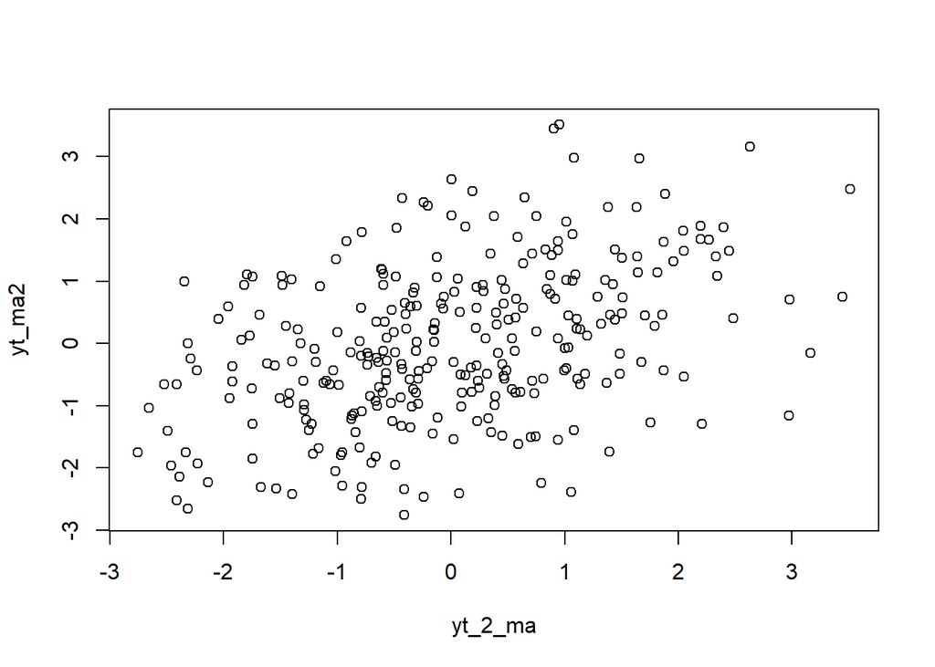

```r
plot(y=yt_ma2,x=yt_2_ma)
```

Berdasarkan scatterplot tersebut, terlihat bahwa terdapat hubungan positif antara $Y_t$ dengan $Y_{t-2}$.

```r
cor(yt_ma2,yt_2_ma)
```

```
## [1] 0.4181448
```

```r
#Yt
yt_ma3 <- ma[-c(1,2,3)]
yt_ma3
```

```
##   [1] -0.789963494 -0.503164438  0.574562096  0.181639137  0.714347145
##   [6] -0.783357002  1.443197455 -1.095179301  1.505736036 -0.594877317
##  [11]  1.372563561 -0.116767613 -0.636198060 -1.187910662 -0.299505943
##  [16] -0.302193224  0.609626291  0.024934015 -0.782115212 -1.538116763
##  [21] -2.311141894 -2.333091732 -2.655255495 -1.748786669 -1.035412461
##  [26] -0.720936513 -0.433984307 -0.211797639 -1.325140326 -0.404089478
##  [31]  0.007656592  0.645738793  2.633595323  2.345718678  3.163498661
##  [36]  1.081935628 -0.157611023 -1.396693764 -1.451054904 -2.414407376
##  [41]  0.280363696 -0.650674975  0.942686169 -1.001096313 -1.550922655
##  [46]  0.177224350 -0.358702501 -0.393298646  0.588144127  0.236924318
##  [51]  1.706734401 -0.605181572  0.450592241  1.179221257 -0.332172503
##  [56] -0.491942121 -0.734862521 -0.148335885 -0.149759801  0.217872770
##  [61]  0.022050476  0.248496820 -0.303986309 -0.711768697 -0.122706183
##  [66] -0.850890838  1.060918135 -1.121999133 -2.386798959 -0.631662247
##  [71] -2.137326137 -0.700053984 -2.231252380 -1.921568655 -1.923749010
```

[output cut: 45 more lines]

```r
#Yt-3
yt_3_ma <- ma[-c(298,299,300)]
yt_3_ma
```

```
##   [1]  0.540203928  0.097894590  0.083458434 -0.789963494 -0.503164438
##   [6]  0.574562096  0.181639137  0.714347145 -0.783357002  1.443197455
##  [11] -1.095179301  1.505736036 -0.594877317  1.372563561 -0.116767613
##  [16] -0.636198060 -1.187910662 -0.299505943 -0.302193224  0.609626291
##  [21]  0.024934015 -0.782115212 -1.538116763 -2.311141894 -2.333091732
##  [26] -2.655255495 -1.748786669 -1.035412461 -0.720936513 -0.433984307
##  [31] -0.211797639 -1.325140326 -0.404089478  0.007656592  0.645738793
##  [36]  2.633595323  2.345718678  3.163498661  1.081935628 -0.157611023
##  [41] -1.396693764 -1.451054904 -2.414407376  0.280363696 -0.650674975
##  [46]  0.942686169 -1.001096313 -1.550922655  0.177224350 -0.358702501
##  [51] -0.393298646  0.588144127  0.236924318  1.706734401 -0.605181572
##  [56]  0.450592241  1.179221257 -0.332172503 -0.491942121 -0.734862521
##  [61] -0.148335885 -0.149759801  0.217872770  0.022050476  0.248496820
##  [66] -0.303986309 -0.711768697 -0.122706183 -0.850890838  1.060918135
##  [71] -1.121999133 -2.386798959 -0.631662247 -2.137326137 -0.700053984
```

[output cut: 45 more lines]

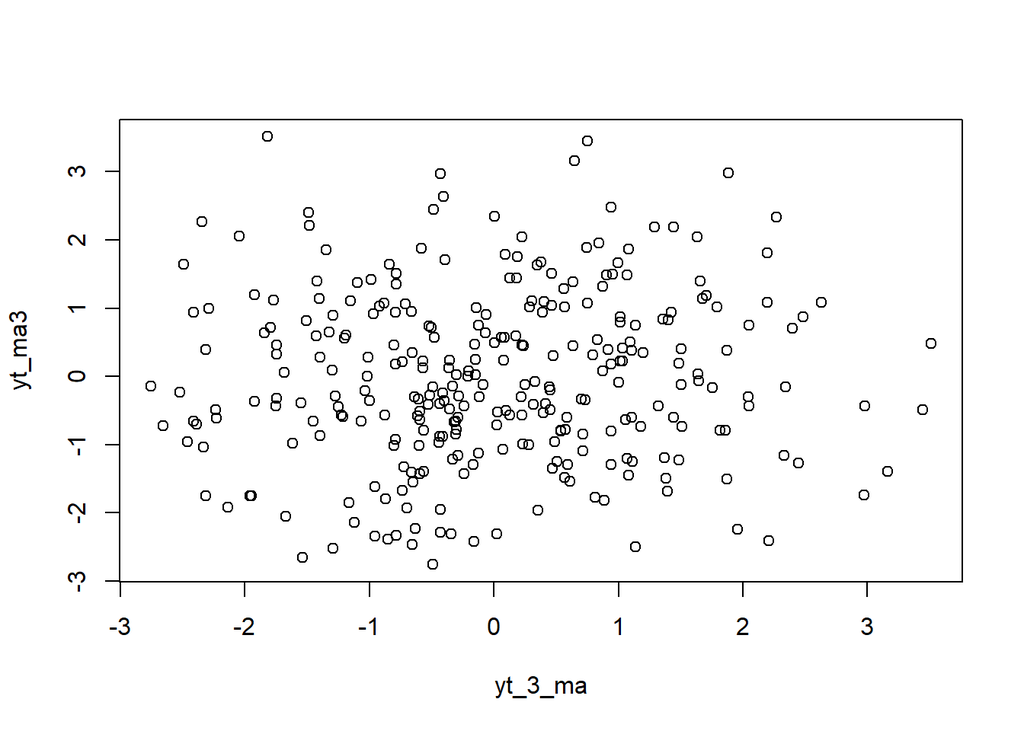

```r
plot(y=yt_ma3,x=yt_3_ma)
```

Berdasarkan scatterplot tersebut, terlihat bahwa cenderung tidak terdapat hubungan antara $Y_t$ dengan $Y_{t-3}$.

```r
cor(yt_ma3,yt_3_ma)
```

```
## [1] 0.0556338
```